# 03_modelFitting_testingBetaLASSO

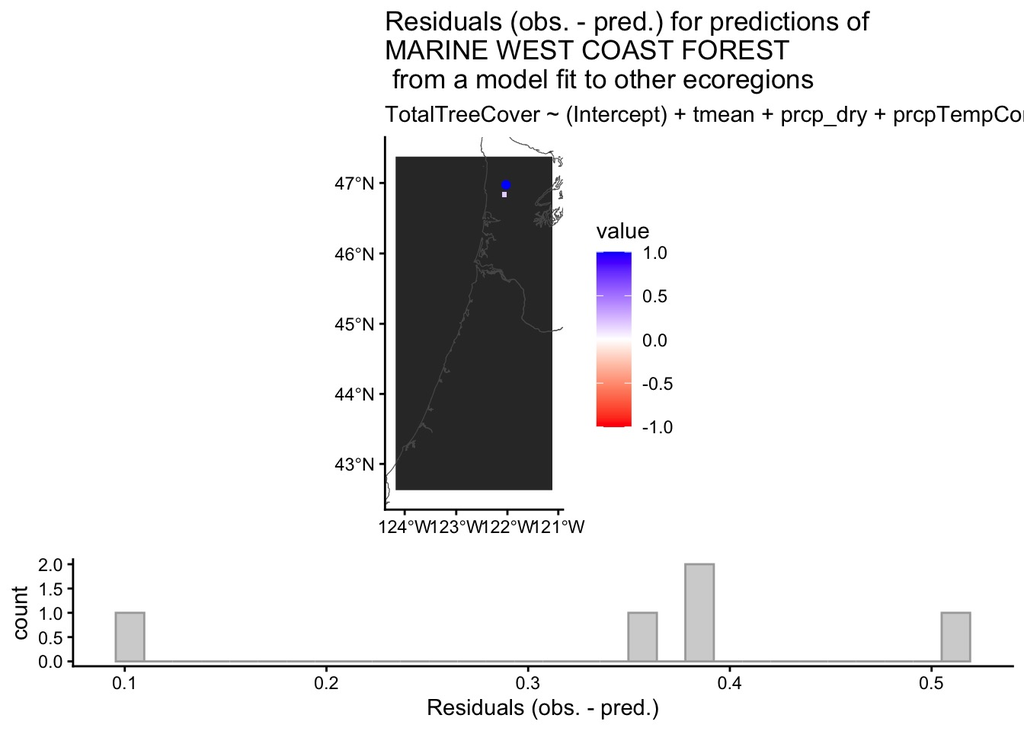

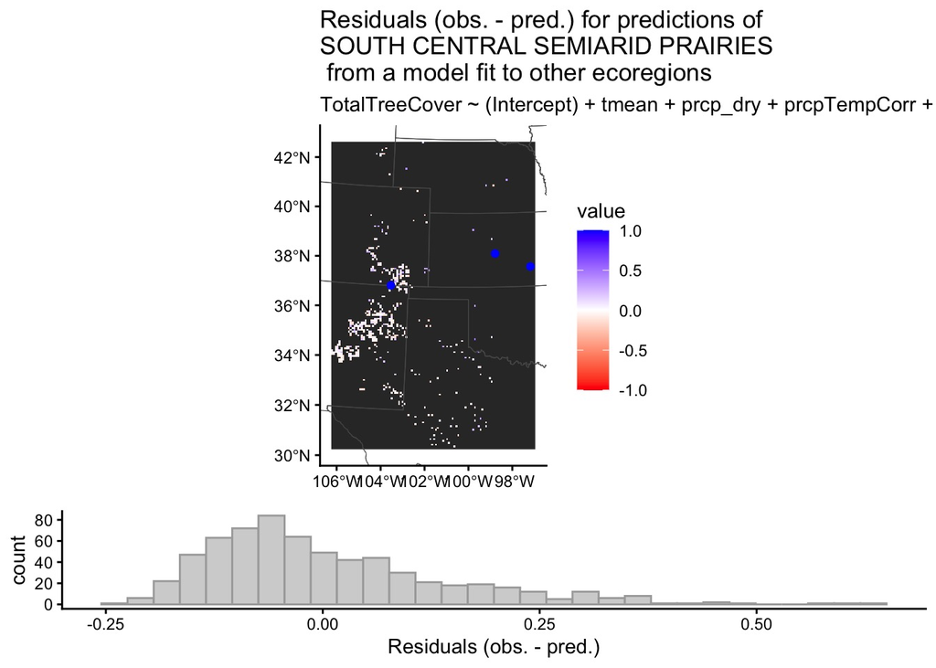

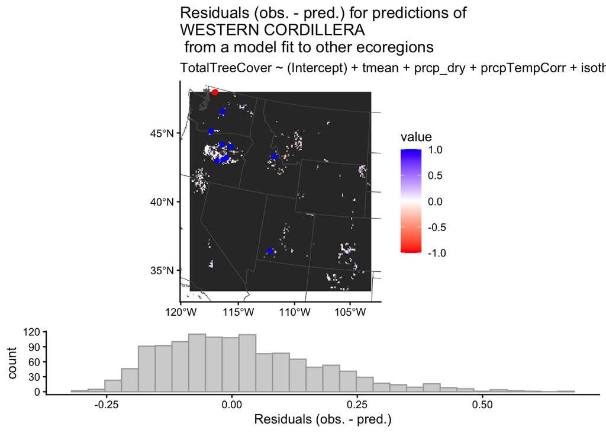

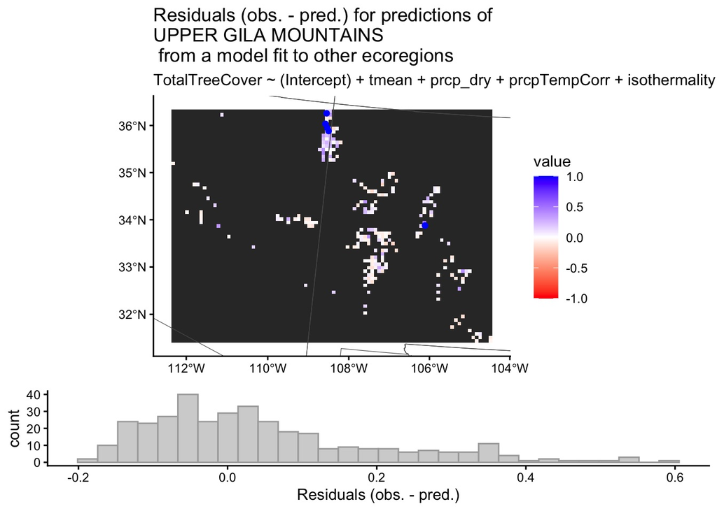

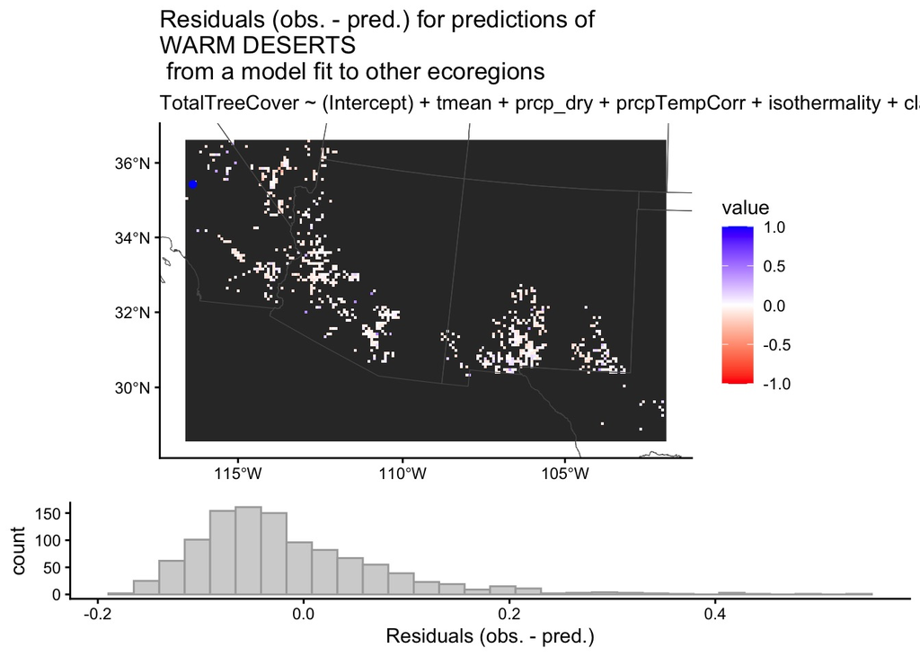

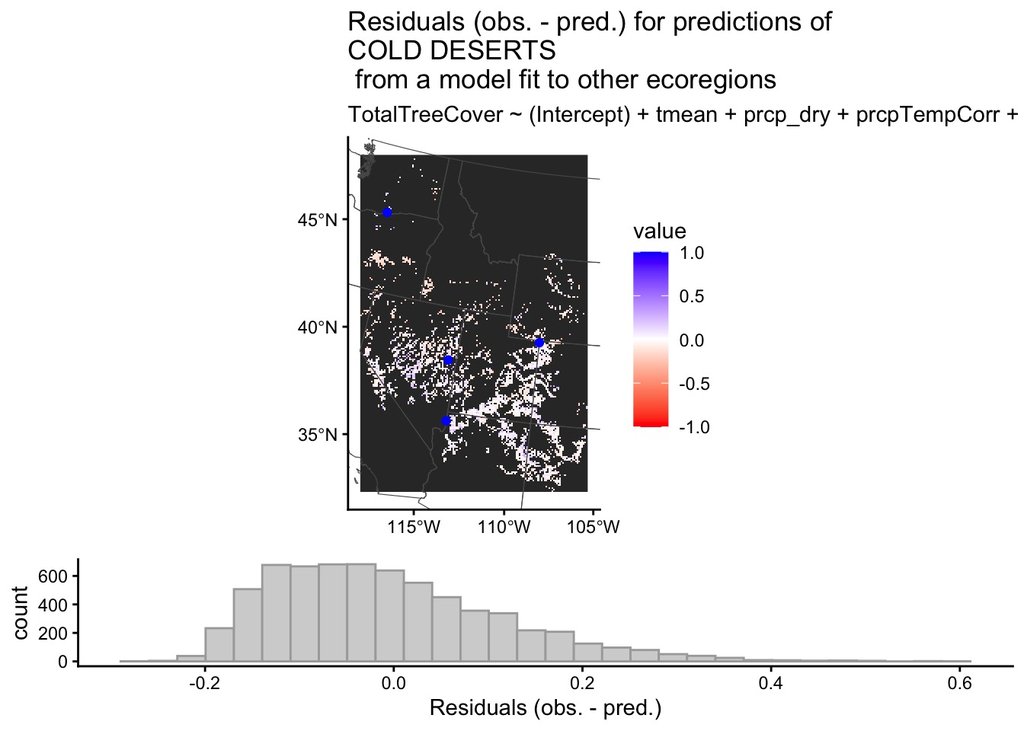

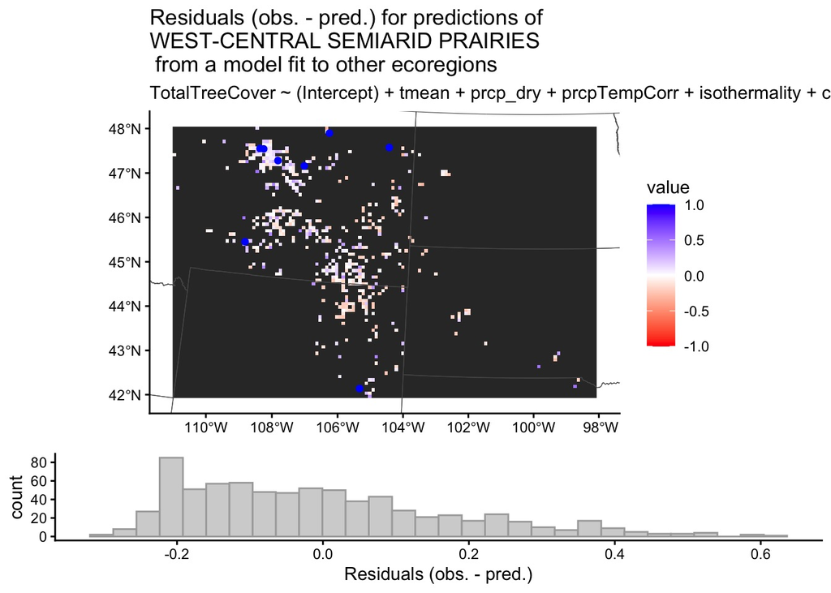

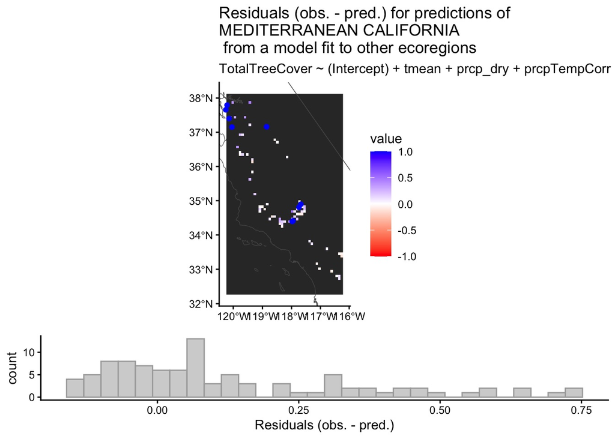

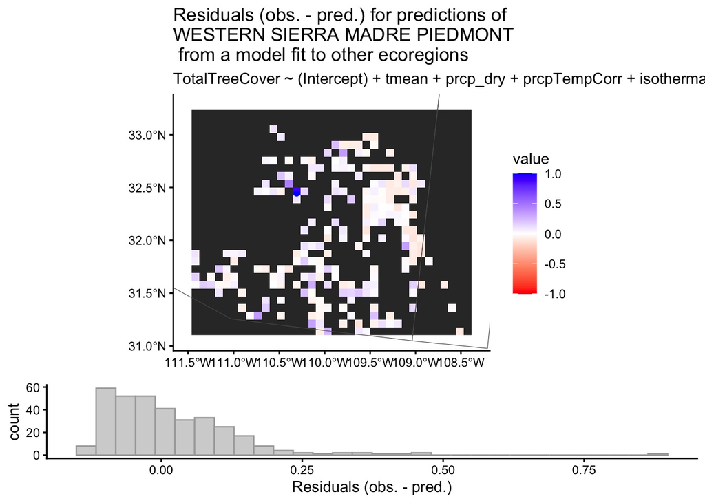

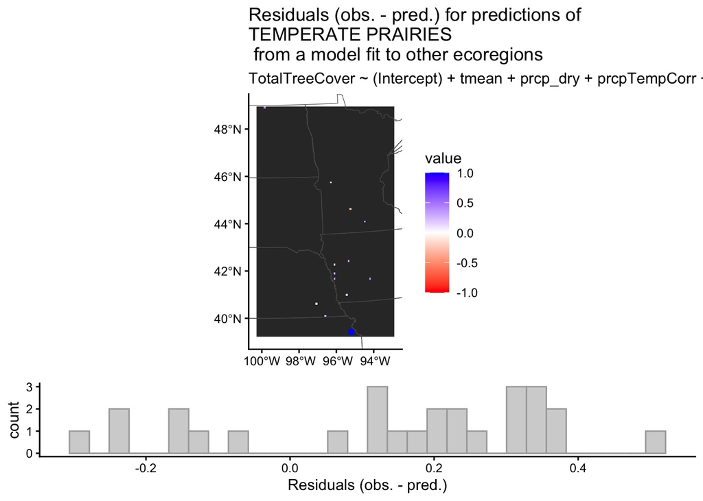

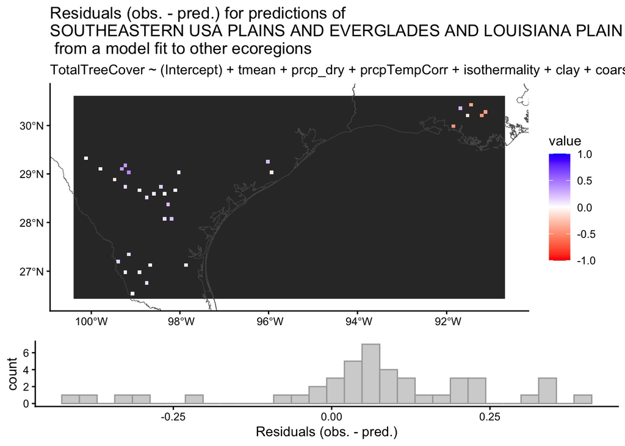

[figure not shown]

```r
# visualize model predictions
for (i in 1:length(unique(modDat_1_s$NA_L2NAME))) {
  holdoutRegion <- outList[[i]]$testRegion
  predictionData <- outList[[i]]$modelPredictions
  modTerms <- as.matrix(coef(outList[[i]]$modelObject)) %>%
    as.data.frame() %>%
    filter(V1!=0) %>%
    rownames()

  # calculate residuals
  predictionData <- predictionData %>%
  mutate(resid = .[["obs"]] - .[["pred_opt"]] ,
         resid_globMod = .[["obs"]]  - .[["pred_null"]])

# rasterize
# use 'test_rast' from earlier

  # rasterize data
plotObs <- predictionData %>%
         drop_na(paste(response)) %>%
  #slice_sample(n = 5e4) %>%
  terra::vect(geom = c("x", "y")) %>%
  terra::set.crs(crs(crs_veg)) %>%
  terra::project(crs(test_rast)) %>%
  terra::rasterize(y = test_rast,
                   field = "resid",
                   fun = mean) #%>%
  #terra::aggregate(fact = 2, fun = mean, na.rm = TRUE) %>%
  #terra::crop(ext(-1950000, 1000000, -1800000, 1000000))

tempExt <- crds(plotObs, na.rm = TRUE)
plotObs_2 <- plotObs %>%
  crop(ext(
    min(tempExt[,1]), max(tempExt[,1])+1,
           min(tempExt[,2]), max(tempExt[,2])+1
    )
       )

# identify locations where residuals are >100 or < -100
badResids_high <- predictionData %>%
  filter(resid > .5)  %>%
  terra::vect(geom = c("x", "y")) %>%
  terra::set.crs(crs(crs_veg)) %>%
  terra::project(crs(test_rast))
badResids_low <- predictionData %>%
  filter(resid < -.5)  %>%
  terra::vect(geom = c("x", "y")) %>%
  terra::set.crs(crs(crs_veg)) %>%
  terra::project(crs(test_rast))

# make figures
# make histogram
hist_i <- ggplot(predictionData) +
  geom_histogram(aes(resid_globMod), col = "darkgrey", fill = "lightgrey") +
  xlab(c("Residuals (obs. - pred.)"))
# make map
map_i <-  ggplot() +
geom_spatraster(data = plotObs_2) +
  geom_sf(data=cropped_states, fill=NA ) +
  geom_sf(data = badResids_high, col = "blue") +
  geom_sf(data = badResids_low, col = "red") +
labs(title = paste0("Residuals (obs. - pred.) for predictions of \n", holdoutRegion, " \n from a model fit to other ecoregions"),
     subtitle = paste0(response, " ~ ", paste0( modTerms, collapse = " + "))) +
  scale_fill_gradient2(low = "red",
                       mid = "white" ,
                       high = "blue" ,
                       midpoint = 0,   na.value = "grey20",
                       limits = c(-1, 1)) +
  xlim(c(min(tempExt[,1]), max(tempExt[,1])+1)) +
  ylim(c(min(tempExt[,2]), max(tempExt[,2])+1))

 assign(paste0("residPlot_",holdoutRegion),
   value = ggarrange(map_i, hist_i, heights = c(3,1), ncol = 1)
)

}

  lapply(unique(modDat_1_s$NA_L2NAME), FUN = function(x) {
    get(paste0("residPlot_", x))
  })
```

## Using second best lambda model (either 1se or 1/2se)

### Use terms from global model to re-fit and predict on different held out regions

### Figures show residuals for each of the models fit to held-out ecoregions

```r
if (length(prednames_secondBestMod) == 0) {
  print("The model only contains one predictor (an intercept), so cross validation isn't practical")
} else {

## code from Tredennick et al. 2020
# try each separate level II ecoregion as a test set
# make a list to hold output data
outList <- vector(mode = "list", length = length(sort(unique(modDat_1_s$NA_L2NAME))))
# obs_pred <- data.frame(ecoregion = character(),obs = numeric(),
#                        pred_opt = numeric(), pred_null = numeric()#,
#                        #pred_nopenalty = numeric()
#                        )

## get the model specification from the global model
mat <- as.matrix(coef(mod_secondBest, s = "lambda.min"))
mat2 <- mat[mat[,1] != 0,]

f_cv <- as.formula(paste0(response, " ~ ", paste0(names(mat2)[2:length(names(mat2))], collapse = " + ")))

X_cv <- model.matrix(object = f_cv, data = modDat_1_s)
# get response variable
y_cv <- as.matrix(modDat_1_s[,response])


# now, loop through so with each iteration, a different ecoregion is held out
 for(i_eco in sort(unique(modDat_1_s$NA_L2NAME))){

  # split into training and test sets
  test_eco <- i_eco
  print(test_eco)
  # identify the rowID of observations to be in the training and test datasets
  train <- which(modDat_1_s$NA_L2NAME!=test_eco) # data for all ecoregions that aren't 'i_eco'
  test <- which(modDat_1_s$NA_L2NAME==test_eco) # data for the ecoregion that is 'i_eco'

  trainDat_all <- modDat_1_s %>%
    slice(train) %>%
    dplyr::select(-newRegion)
  testDat_all <- modDat_1_s %>%
    slice(test) %>%
    dplyr::select(-newRegion)
## make testDat_all a data.frame that matches data used for fit_glm_bestLambda model (fit to matrix)
testDat_DF <- data.frame(X[test,2:ncol(X)])
names(testDat_DF) <- colnames(X)[2:ncol(X)]
  # get the model matrices for input and response variables for cross validation model specification
  X_train <- as.matrix(X_cv[train,])
  X_test <- as.matrix(X_cv[test,])

  y_train <- modDat_1_s[train,response]
  y_test <- modDat_1_s[test,response]

  # get the model matrices for input and response variables for original model specification
  X_train_glob <- as.matrix(X[train,])
  X_test_glob <- as.matrix(X[test,])

  y_train_glob <- modDat_1_s[train,response]
  y_test_glob <- modDat_1_s[test,response]

  train_eco <- modDat_1_s$NA_L2NAME[train]

  ## just try a regular glm w/ the components from the global model
  fit_i <- glm(data = trainDat_all, formula = f_cv,
    ,
               family =  quasibeta_family(link = "logit")
    )

    coef(fit_i)

  # lasso model predictions with the optimal lambda
  optimal_pred <- predict(fit_i, newdata= testDat_all, type = "response")
  # null model and predictions
  # the "null" model in this case is the global model
  # predict on the test data for this iteration w/ the global model
  null_pred <- predict.glm(mod_secondBest, newdata = testDat_DF, type = "response")

  # save data
  tmp <- data.frame(ecoRegion_holdout = rep(test_eco,length(y_test)),
                    obs=y_test,
                    pred_opt=optimal_pred,
                    pred_null=null_pred#,
                    #pred_nopenalty=nopen_pred
                    ) %>%
    cbind(testDat_all)

  # calculate RMSE, bias, etc. of
  # RMSE of CV model
  RMSE_optimal <- yardstick::rmse(data = data.frame(optimal_pred, "y_test" = (y_test)), truth = "y_test", estimate = "optimal_pred")[1,]$.estimate
  # RMSE of global model
  RMSE_null <- yardstick::rmse(data = data.frame(null_pred,  "y_test" = (y_test)), truth = "y_test", estimate = "null_pred")[1,]$.estimate
  # bias of CV model
  bias_optimal <- mean((y_test) - optimal_pred)
  # bias of global model
  bias_null <-  mean((y_test) - null_pred )

  # put output into a list
  tmpList <- list("testRegion" = i_eco,
    "modelObject" = fit_i,
       "modelPredictions" = tmp,
    "performanceMetrics" = data.frame("RMSE_cvModel" = RMSE_optimal,
                                      "RMSE_globalModel" = RMSE_null,
                                      "bias_cvModel" = bias_optimal,
                                      "bias_globalModel" = bias_null))

  # save model outputs
  outList[[which(sort(unique(modDat_1_s$NA_L2NAME)) == i_eco)]] <- tmpList
 }
}
```

```
## [1] "COLD DESERTS"
## [1] "MARINE WEST COAST FOREST"
## [1] "MEDITERRANEAN CALIFORNIA"
## [1] "MIXED WOOD SHIELD"
## [1] "SOUTH CENTRAL SEMIARID PRAIRIES"
## [1] "SOUTHEASTERN USA PLAINS AND EVERGLADES AND LOUISIANA PLAIN"
## [1] "TEMPERATE PRAIRIES"
## [1] "UPPER GILA MOUNTAINS"
## [1] "WARM DESERTS"
## [1] "WEST-CENTRAL SEMIARID PRAIRIES"
## [1] "WESTERN CORDILLERA"
## [1] "WESTERN SIERRA MADRE PIEDMONT"
```

### Below are the RMSE and bias values for predictions made for each holdout level II ecoregion, compared to predictions from the global model for that same ecoregion

```r
if (length(prednames_secondBestMod) == 0) {
  print("The model only contains one predictor (an intercept), so cross validation isn't practical")
} else {
# table of model performance
purrr::map(outList, .f = function(x) {
  cbind(data.frame("holdout region" = x$testRegion),  x$performanceMetrics)
}
) %>%
  purrr::list_rbind() %>%
  kable(col.names = c("Held-out ecoregion", "RMSE of CV model", "RMSE of global model",
                      "bias of CV model - mean(obs-pred.)", "bias of global model - mean(obs-pred.)"),
        caption = "Performance of Cross Validation using 'second best lambda' model specification") %>%
kable_styling(bootstrap_options = c("striped", "hover", "condensed"))
}
```

Performance of Cross Validation using ‘second best lambda’ model specification

| Held-out ecoregion | RMSE of CV model | RMSE of global model | bias of CV model - mean(obs-pred.) | bias of global model - mean(obs-pred.) |
| --- | --- | --- | --- | --- |
| COLD DESERTS | 0.1277774 | 0.1196505 | -0.0469787 | -0.0164365 |
| MARINE WEST COAST FOREST | 0.4757024 | 0.4754743 | 0.4591387 | 0.4589045 |
| MEDITERRANEAN CALIFORNIA | 0.2726935 | 0.2713943 | 0.1490758 | 0.1465877 |
| MIXED WOOD SHIELD | 0.2821765 | 0.2817452 | 0.2765002 | 0.2760602 |
| SOUTH CENTRAL SEMIARID PRAIRIES | 0.1516819 | 0.1510576 | 0.0396246 | 0.0370182 |
| SOUTHEASTERN USA PLAINS AND EVERGLADES AND LOUISIANA PLAIN | 0.1909888 | 0.1897409 | 0.0790956 | 0.0778652 |
| TEMPERATE PRAIRIES | 0.4802614 | 0.4783538 | 0.4148467 | 0.4126880 |
| UPPER GILA MOUNTAINS | 0.1548055 | 0.1543822 | 0.0432358 | 0.0419515 |
| WARM DESERTS | 0.0954850 | 0.0933161 | -0.0246030 | -0.0141034 |
| WEST-CENTRAL SEMIARID PRAIRIES | 0.1809601 | 0.1808606 | 0.0142999 | 0.0126971 |
| WESTERN CORDILLERA | 0.1656052 | 0.1641201 | 0.0392807 | 0.0321013 |
| WESTERN SIERRA MADRE PIEDMONT | 0.1152043 | 0.1148782 | 0.0153413 | 0.0129800 |

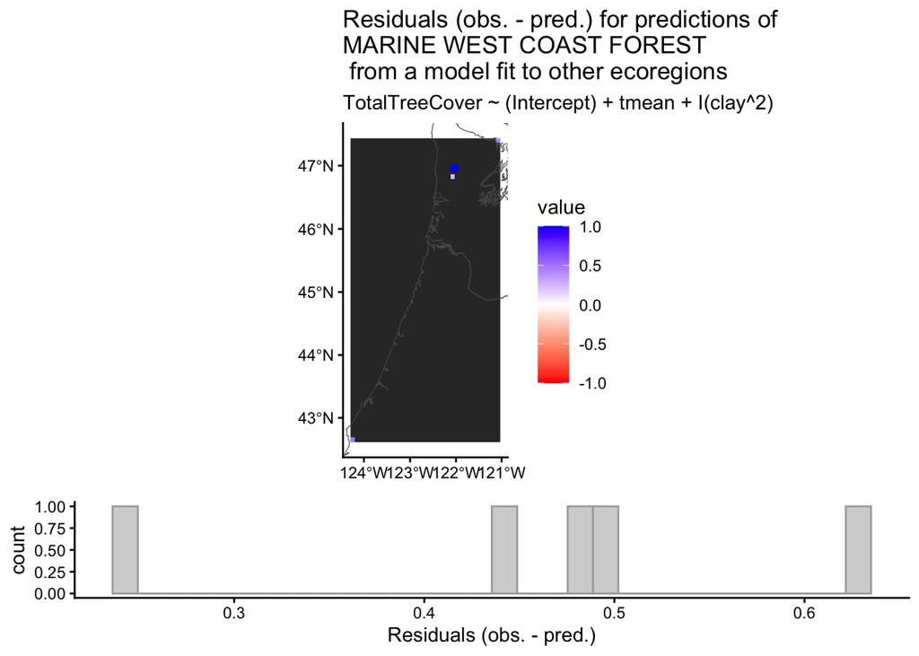

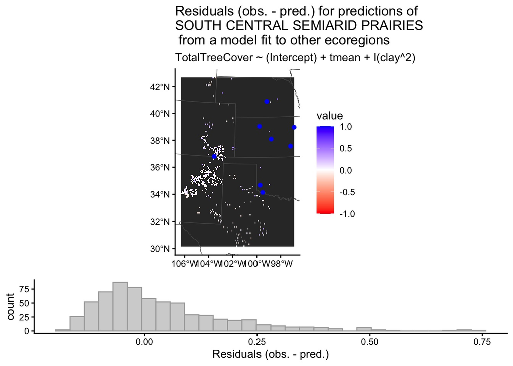

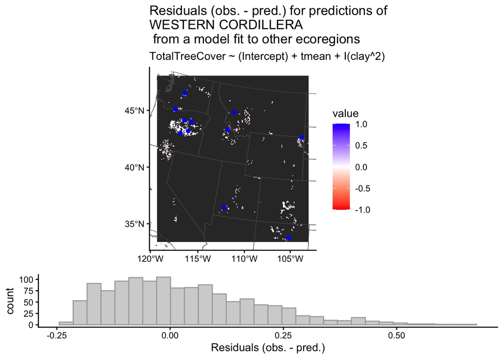

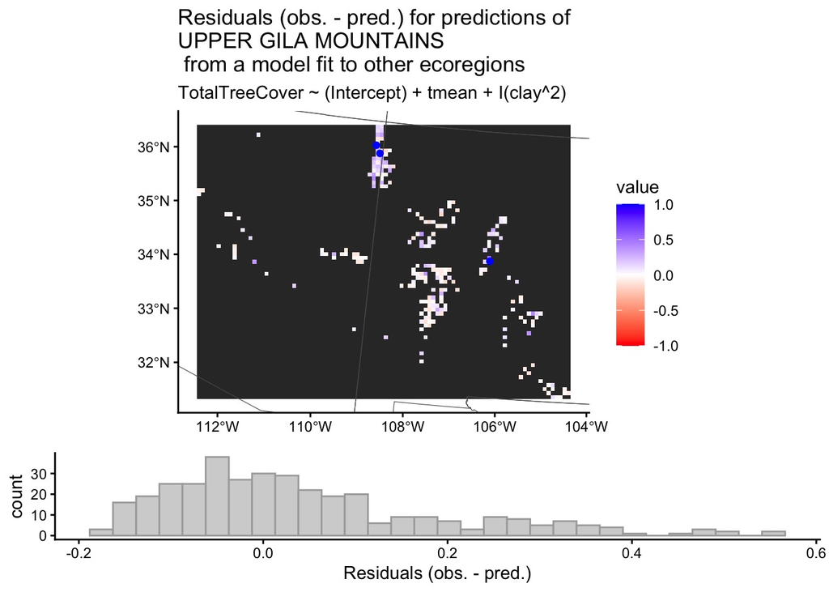

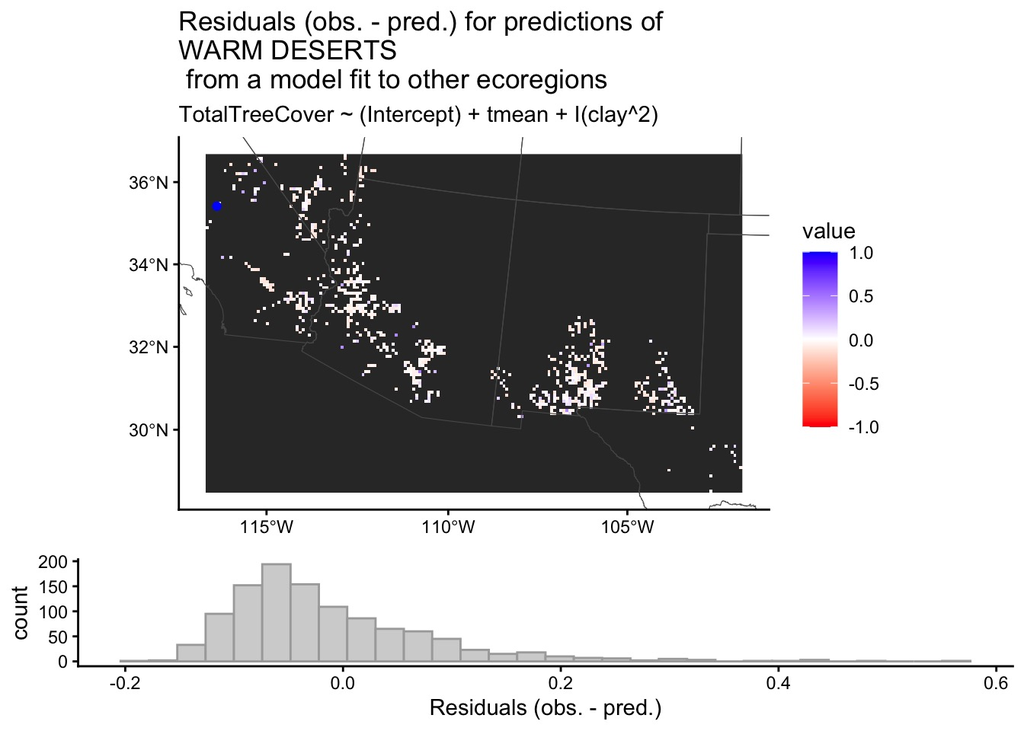

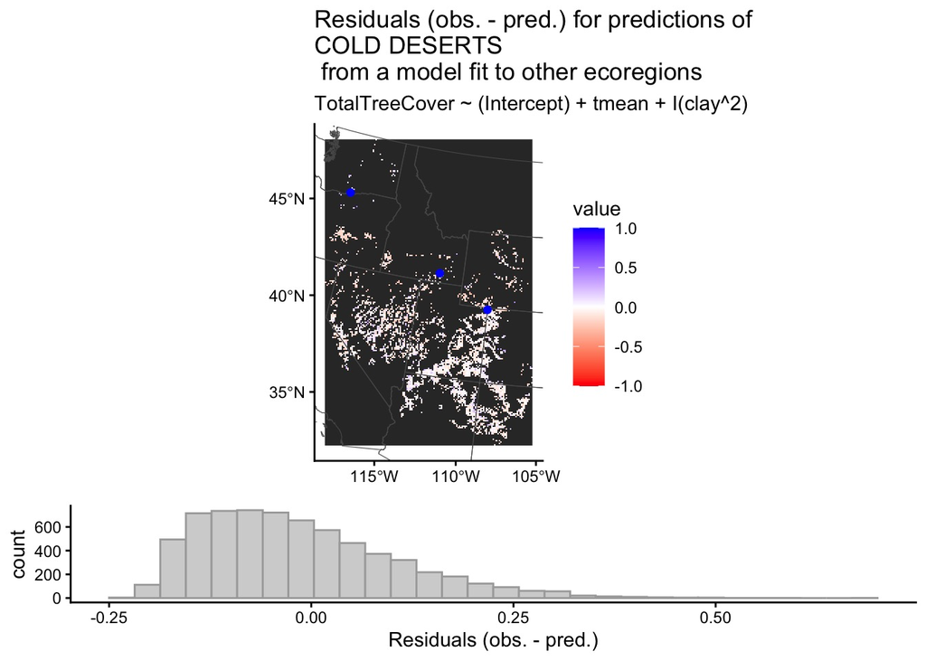

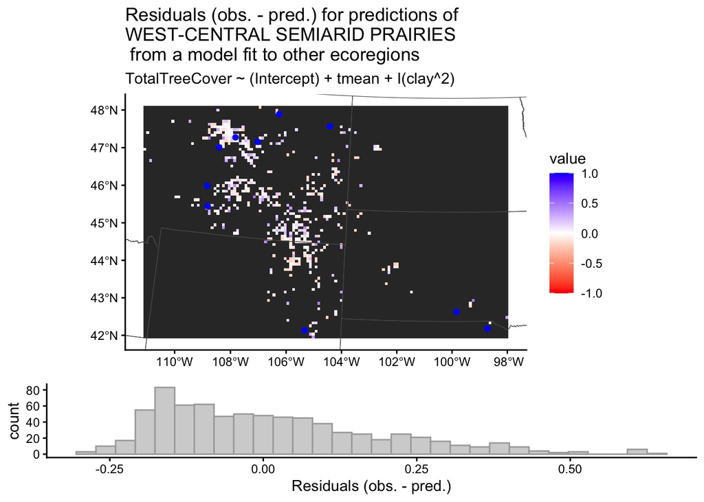

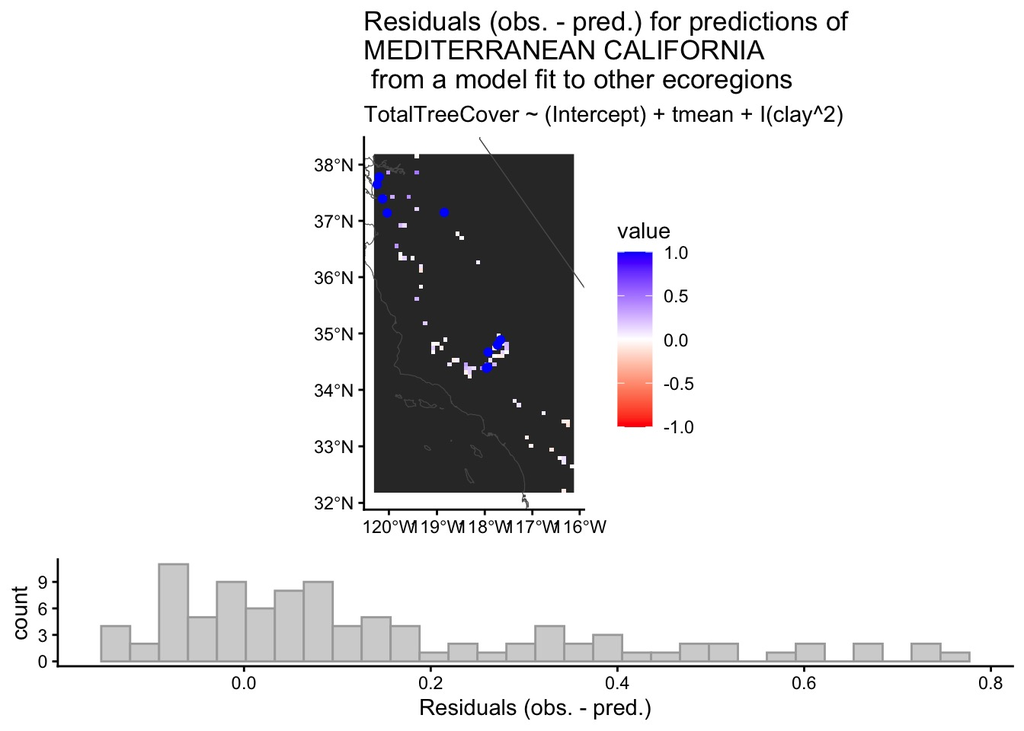

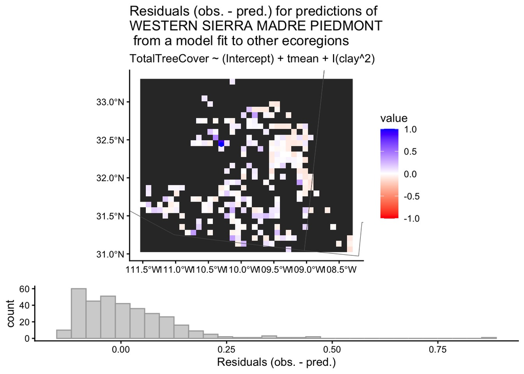

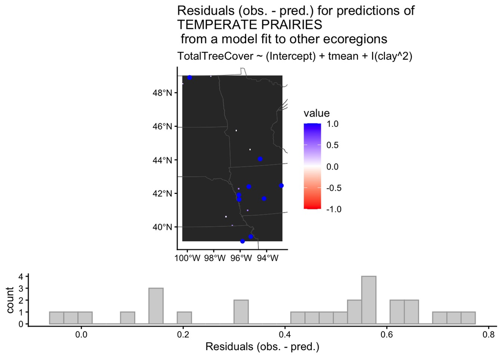

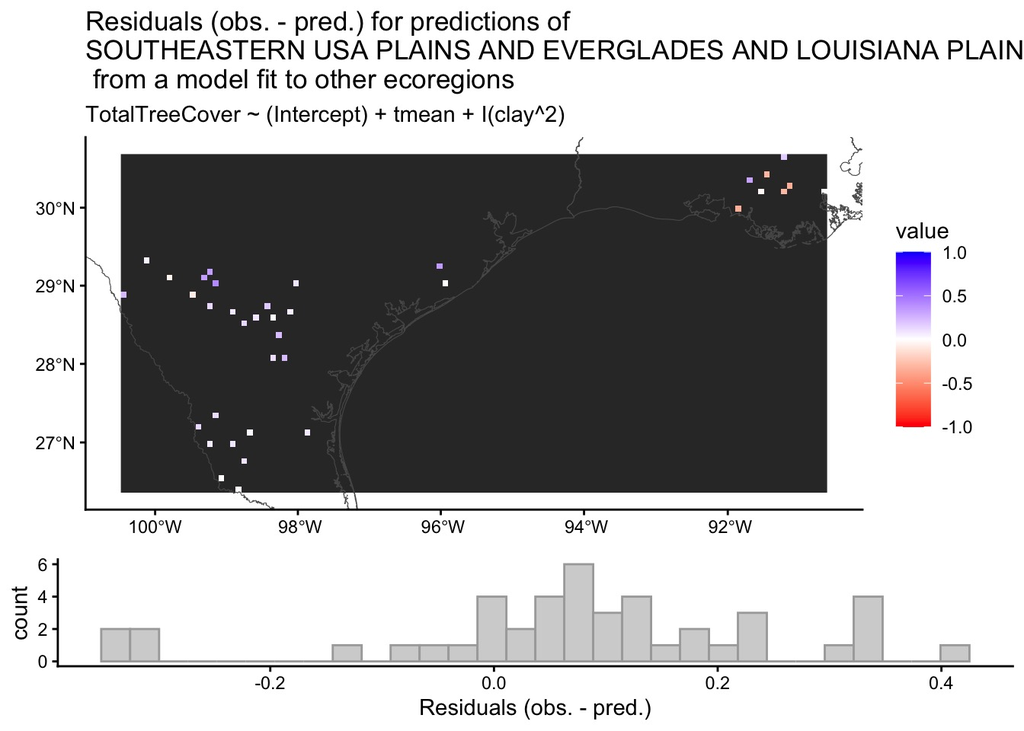

[figure not shown]

```r
if (length(prednames_secondBestMod) == 0) {
  print("The model only contains one predictor (an intercept), so cross validation isn't practical")
} else {
for (i in 1:length(unique(modDat_1_s$NA_L2NAME))) {
  holdoutRegion <- outList[[i]]$testRegion
  predictionData <- outList[[i]]$modelPredictions
  modTerms <- as.matrix(coef(outList[[i]]$modelObject)) %>%
    as.data.frame() %>%
    filter(V1!=0) %>%
    rownames()

  # calculate residuals
  predictionData <- predictionData %>%
  mutate(resid = .[["obs"]] - .[["pred_opt"]] ,
         resid_globMod = .[["obs"]]  - .[["pred_null"]])

  # rasterize data
plotObs <- predictionData %>%
         drop_na(paste(response)) %>%
  #slice_sample(n = 5e4) %>%
  terra::vect(geom = c("x", "y")) %>%
  terra::set.crs(crs(crs_veg)) %>%
  terra::project(crs(test_rast)) %>%
  terra::rasterize(y = test_rast,
                   field = "resid",
                   fun = mean) #%>%
  #terra::aggregate(fact = 2, fun = mean, na.rm = TRUE) %>%
  #terra::crop(ext(-1950000, 1000000, -1800000, 1000000))

tempExt <- crds(plotObs, na.rm = TRUE)

plotObs_2 <- plotObs %>%
  crop(ext(min(tempExt[,1]), max(tempExt[,1])+1,
           min(tempExt[,2]), max(tempExt[,2])+1)
       )

# identify locations where residuals are >100 or < -100
badResids_high <- predictionData %>%
  filter(resid > .5)  %>%
  terra::vect(geom = c("x", "y")) %>%
  terra::set.crs(crs(crs_veg)) %>%
  terra::project(crs(test_rast))
badResids_low <- predictionData %>%
  filter(resid < -.5)  %>%
  terra::vect(geom = c("x", "y")) %>%
  terra::set.crs(crs(crs_veg)) %>%
  terra::project(crs(test_rast))


# make figures
# make histogram
hist_i <- ggplot(predictionData) +
  geom_histogram(aes(resid_globMod), col = "darkgrey", fill = "lightgrey") +
  xlab(c("Residuals (obs. - pred.)"))
# make map
map_i <-  ggplot() +
geom_spatraster(data = plotObs_2) +
  geom_sf(data=cropped_states,fill=NA ) +
  geom_sf(data = badResids_high, col = "blue") +
  geom_sf(data = badResids_low, col = "red") +
labs(title = paste0("Residuals (obs. - pred.) for predictions of \n", holdoutRegion, " \n from a model fit to other ecoregions"),
     subtitle = paste0(response, " ~ ", paste0( modTerms, collapse = " + "))) +
  scale_fill_gradient2(low = "red",
                       mid = "white" ,
                       high = "blue" ,
                       midpoint = 0,   na.value = "grey20",
                       limits = c(-1, 1))  +
  xlim(st_bbox(plotObs_2)[c(1,3)]) +
  ylim(st_bbox(plotObs_2)[c(2,4)])

 assign(paste0("residPlot_",holdoutRegion),
   value = ggarrange(map_i, hist_i, heights = c(3,1), ncol = 1)
)

}

  lapply(unique(modDat_1_s$NA_L2NAME), FUN = function(x) {
    get(paste0("residPlot_", x))
  })
}
```

# Save output

```r
## save the coefficients for the models (best lambda, 1/2se lambda, 1se lambda)
if(trimAnom == TRUE) {
saveRDS(coefs, file = paste0("./models/modelCoefficients_trimAnom_", ecoregion, "_", response,"_removeAnomalies", removeAllAnoms,".rds"))
saveRDS(uniqueCoeffs, file = paste0("./models/modelMetrics_trimAnom_", ecoregion, "_", response,"_removeAnomalies", removeAllAnoms,".rds"))
} else {
saveRDS(coefs, file = paste0("./models/modelCoefficients_", ecoregion, "_", response,"_removeAnomalies", removeAllAnoms,".rds"))
saveRDS(uniqueCoeffs, file = paste0("./models/modelMetrics_", ecoregion, "_", response,"_removeAnomalies", removeAllAnoms,".rds"))
}
# make a table
```

```r
## partial dependence plots
#vip::vip(mod_glmFinal, num_features = 15)

#pdp_all_vars(mod_glmFinal, mod_vars = pred_vars, ylab = 'probability',train = df_small)

#caret::varImp(fit)
```

# session info

Hash of current commit (i.e. to ID the version of the code used)

```r
system("git rev-parse HEAD", intern=TRUE)
```

```
## [1] "38d71d348cb989a1f9fa1a14967a909a2585e2af"
```

Packages etc.